# Some words about reproducible research

UiT Tromsø, 21 June 2016

## Definition

- *Reproducibility is the ability of an entire experiment or study to be duplicated, either by the same researcher or by someone else working independently.* (Wikipedia)
- Reproducibility is enhanced if analysis (including source code) and results are saved in well documented, transparent and portable supports so that:
  - anyone can rerun the original analysis
  - authors do not get lost in a sea of different versions, trying to match the latest script file with the latest text version.

## Tools for research with statistical contents

- RStudio: authoring contents with text and R output
  - R Markdown: reports in word, html, pdf (latex-style) and presentations in html
  - R presentations
  - Sweave: reports and presentations on pdf (latex)
  - Shiny: interactive widgets
- Jupyter and Python notebook: interactive notebooks
- Git and Github: control version, allows to work on same files with collaborators
- Overleaf: collaborative writing

## R Markdown

- Not a WYSIWYG (*what you see is what you get*) authoring system such as MS word and Powerpoint: what you type is *almost* what you get
- Easy syntax for writing text paragraphs and tables (though a bit simplistic)
- Allows LaTeX syntax for mathematical formulas
- Easy to embed R code 'chunks' to render plots and output data summary.
- The output file is automatically updated when code and/or data change.

## Example: slide with R output

```r
summary(pressure)
```

```
##   temperature     pressure
##  Min.   :  0   Min.   :  0.0002
##  1st Qu.: 90   1st Qu.:  0.1800
##  Median :180   Median :  8.8000
##  Mean   :180   Mean   :124.3367
##  3rd Qu.:270   3rd Qu.:126.5000
##  Max.   :360   Max.   :806.0000
```

## Example: slide with R output

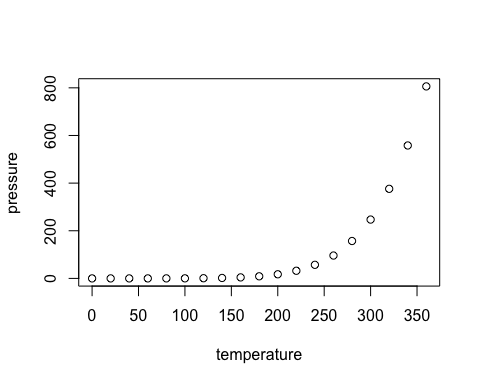

```r
plot(pressure)
```

## Learn R Markdown!

- Many tutorials can be found online. Search a combination of 'R Markdown', 'reproducible research', 'github'…
- For instance:
  - https://rpubs.com/marschmi/105639
  - R.D. Peng's Mooc: https://www.coursera.org/learn/reproducible-research